# Customer churn prediction in the online gambling industry: The beneficial effect of ensemble learning - ScienceDirect

[figure not shown]

## [Journal of Business Research](https://www.sciencedirect.com/science/journal/01482963)

[Volume 66, Issue 9](https://www.sciencedirect.com/science/journal/01482963/66/9), September 2013, Pages 1629-1636

# Customer churn prediction in the online gambling industry: The beneficial effect of ensemble learning

[KristofCoussement](https://www.sciencedirect.com/science/article/pii/S0148296312003530?via%3Dihub#!)[Koen W.De Bock](https://www.sciencedirect.com/science/article/pii/S0148296312003530?via%3Dihub#!)

https://doi.org/10.1016/j.jbusres.2012.12.008[Get rights and content](https://s100.copyright.com/AppDispatchServlet?publisherName=ELS&contentID=S0148296312003530&orderBeanReset=true)

## Abstract

The online gambling industry is one of the most revenue generating branches of the entertainment business, resulting in fierce competition and saturated markets. Therefore it is essential to efficiently retain gamblers. Churn prediction is a promising new alternative in customer relationship management (CRM) to analyze customer retention. It is the process of identifying gamblers with a high probability to leave the company based on their past behavior. This study investigates whether churn prediction is a valuable option in the CRM palette of the online gambling companies. Using real-life data of poker players at bwin, single algorithms, CART decision trees and generalized additive models are benchmarked to their ensemble counterparts, random forests and GAMens. The results show that churn prediction is a valuable strategy to identify and profile those customers at risk. Furthermore, the performance of the ensembles is more robust and better than the single models.

## Keywords

Customer relationship management

Online gambling

Customer churn prediction

Ensemble algorithms

GAMens

Random forests

## 1. Introduction

Online gambling is an upcoming trend in today's society due to the digitalization and availability of new technologies, and its popularity is reflected by a tremendous amount of academic research studies (e.g. Smith, Levere, & Kurtzman, 2009). For instance, the online poker market has grown everywhere in the world, accounting for an estimated $3.6 billion in total revenues (Fiedler & Wilcke, 2011). Popular online gambling activities involve sports betting, virtual poker, and traditional casino games.

Previous research mainly focuses on the psychological facets of gambling behavior (Bleichrodt and Schmidt, 2002, Lam, 2006, Lam, 2007, McDaniel and Zuckerman, 2003, Mowen et al., 2009), while other research papers investigate the determinants of individual differences amongst gamblers (e.g. Cronce and Corbin (2010)). Thus far, business and marketing literature approaches gambling from a purely exploratory insight perspective. In detail, former research gives insight into the individual betting behavior (Andrade and Iyer, 2009, Grant and Xie, 2007, Seybert and Bloomfield, 2009, Smith et al., 2009), the legitimation and development process of gambling and the impact on residents' perceptions (Humphreys, 2010, Roehl, 1999), the forecasting possibility of the outcomes of sporting events (Stekler, Sendor, & Verlander, 2010), the gambling agents' learning processes (Dana & Knetter, 1994), etc.

Although Oh and Hsu (2001) report that past gambling behavior impacts future gambling activities and that later on, several researchers tested the impact of past (aggregated) gambling behavior on future gambling behavior (Jolley et al., 2006, Lam, 2006, Lam and Mizerski, 2009, Mizerski et al., 2004), no research study has explored the possibility of using real, individual past gamblers' behavior to predict future behavior to improve the customer relationship management (CRM) of the gambling company. However, gambling companies are searching new approaches to retain customers using their CRM strategy, because the rapid growth of the Internet does not facilitate the choice of the gambling website amongst the many options available (Jolley et al., 2006). Consequently, the CRM literature is expanding (Cooper et al., 2008, Ko et al., 2008) and the fight to maintain the current players' base is a very important challenge within the gambling industry nowadays (Lal, Martone Carrolo, & Harrah's entertainment, 2001).

Since the concept of problem gambling is associated with the retention of gamblers, major gambling companies are actively approaching their players with targeted marketing actions to continue playing (Jolley et al., 2006, National Gambling Impact Study Commission, 1999, Productivity Commission, 1999). Indeed, in accordance with retailers and financial service providers, a lot of gambling companies realize that collecting customer data and storing the information into a customer database is an essential element in their retention strategy (Athanassopoulos, 2000).

Customer churn prediction is one of the key activities of a proactive retention strategy (Keaveney & Parthasarathy, 2001). Customer churn prediction is the process of assigning a probability of future churning behavior to each gambler in the database by building a prediction model based on past information. Intuitively, customers' past behavior is in line with their future gambling behavior. A good churn prediction model is a model that is able to assign high churn probabilities to real churners, and low churn probabilities otherwise. Practically, the marketing analyst uses the churn probabilities of the prediction model to rank the customers from most likely to leave the company to least likely to leave the company. The top X% of customers, containing on average more churners than the random model, are used for the company's targeted retention campaign.

Neslin, Gupta, Kamakura, Lu, and Mason (2006) indicate that numerous steps in the customer churn prediction process have an impact on its success. However, they strongly suggest focusing on the prediction technique due to its huge impact on the return on investment of subsequent marketing actions. As a result, academic literature on the optimization of churn prediction algorithms has exploded in the last few years. Prediction algorithms that are used in customer churn prediction literature include *single algorithms* like decision trees (Lemmens & Croux, 2006), generalized additive models (Coussement, Benoit, & Van den Poel, 2010), logistic regression (Smith, Willis, & Brooks, 2000) or support vector machines (Coussement & Van den Poel, 2008), etc., and *ensemble learners* that combine the predictions of multiple single algorithms (e.g. random forests (Coussement & Van den Poel, 2009)).

This paper introduces the concept of customer churn prediction in the gambling literature, whereas its value as an additional instrument in the CRM toolbox is investigated. Section 2 describes the predictive modeling methodology. Moreover, Section 3 digs into the churn prediction algorithms. Section 4 describes the evaluation metrics used, while Section 5 gives more insight into the real-life gambling dataset. Furthermore, the results are described in Section 6. Finally, the managerial implications for customer churn prediction and the use of ensemble methods are discussed in Section 7, while Section 8 concludes this research paper.

## 2. Predictive modeling methodology

The purpose of predictive modeling is to predict what is likely to happen in the future based upon what happened in the past (Blattberg, Kim, & Neslin, 2008). In the context of CRM, predictive modeling uses historical transactions and characteristics of a customer to predict future customer behavior.

In predictive modeling, two distinct phases are identified, i.e. a training phase and a prediction or test phase. In the training phase, a model that links future customer behavior to historical customer information is created using a training dataset. This dataset consists of input variables and a target variable for a range of customers. The input variables describe the customers' profiles and their past behavior in a certain time period, and usually include demographic characteristics and historical transactions. The latter category includes the popular RFM variables (McCarty & Hastak, 2007), i.e. the recency of customer purchases (R), the purchase frequency (F) and the monetary value of the historical transactions (M). Several studies show that RFM variables are amongst the strongest performing variables in explaining future customer behavior (e.g. Bose & Chen, 2009). The target variable reflects the behavior of interest to be predicted in a subsequent period of time. In the case of customer churn prediction, the target variable is represented by a binary variable representing whether or not a customer churned during the observation period. The purpose of training a predictive model is trying to capture the relationship between the input variables and the target variable.

In the prediction or test phase, the trained model is deployed on data not used during model training, i.e. the test set. Indeed, a test set of customers that are not included in the training process is used to assess the quality of the predictions output by the model. Measuring the performance on unseen data better reflects the true prediction performance, because measuring the performance on the training dataset often results in finding idiosyncratic patterns in the training dataset that do not hold up in a real-life test setting. As such, the original dataset is randomly split into a training set and a test set. In order to disclose the true capabilities of a prediction algorithm, it is good practice to repeat the training phase multiple times in order to reduce the risk of erroneously identifying a particular model as a good model (Malthouse, 2001). This objective is pursued in the cross-validation methodology as suggested by Witten and Frank (2000) and already implemented in a variety of predictive modeling settings in marketing (e.g. Cui, Wong, & Lui, 2006). In this study, results are based upon a five times twofold cross-validation procedure (5 × 2-fold cv). This involves five replications of a twofold cross-validation. In each replication, customers of the original dataset are randomly assigned to one of two equally-sized cross-validation parts. One part is once used as training data to build the prediction model, while the performance is calculated for the other part acting as a test dataset. This process is then repeated, switching the roles of the two cross-validation parts. Furthermore before putting a prediction model into practice, it is important to compare its performance to alternative types of prediction models in order to find the best algorithm (Neslin et al., 2006). As such, Section 3 describes the different prediction algorithms used in this research study.

## 3. Churn prediction algorithms

### 3.1. Single algorithms

#### 3.1.1. CART decision tree

Decision trees are popular techniques in predictive modeling due to their simplicity and transparency (Duda, Hart, & Stork, 2001). For instance, Murthy (1998) found more than 300 academic references that use decision trees in a variety of settings. A decision tree is composed of a set of rules that divide a dataset that is heterogeneous in terms of the target variable into smaller, more homogeneous sets. The technique is best explained by referring to its prediction phase. To determine the churn probability of a customer in the test dataset, the customer enters the decision tree at the start or root node at the top of the decision tree. This node represents a test that attributes the customer to one of the lower-level or child nodes. The test is a logical question formulated in terms of the input variable, chosen in such a way that it discriminates maximally between churners and non-churners. The result of the test determines which child node is chosen for the customer. Tests at subsequent child nodes redirect the customer through the decision tree until a terminal or leaf node is reached. The collection of unique paths between the root node and the leaf nodes makes up the rules used to generate predictions. All customers from the test set reaching the same leaf node receive the same prediction probability, calculated as the percentage of churners from all training customers in that leaf node.

This study employs the CART algorithm, acronym for Classification and Regression Trees, because it is a popular decision-tree algorithm using the *Gini coefficient* as splitting criterion (Breiman, Friedman, Olsen, & Stone, 1984). It implements binary recursive partitioning; it uses *two-way splits* that split a node into exactly two child nodes, while its growing process continues recursively until splits are no longer possible because all customers in a node are identical in terms of the target variable or the input variables. Finally, the decision-tree pruning that aims at reducing the decision-tree complexity is necessary, because decision trees are susceptible to overfitting. In CART, pruning is done via the *maximum performance objective criterion* (Breiman et al., 1984, Steinberg and Colla, 1998).

#### 3.1.2. Generalized additive model

The most popular technique among predictive modeling techniques that have been applied to the prediction of customer churn is incontestably logistic regression (Buckinx & Van den Poel, 2005). Its popularity is mainly attributed to its ability to combine the simplicity of a linear model with favorable performance, and its widespread availability in many statistical and data-mining software environments like SAS, IBM SPSS Modeler, R, WEKA, etc. However in several studies (e.g. Coussement et al., 2010), it has been shown how more advanced prediction techniques like generalized additive models (GAM) significantly outperform logistic regression. A particular limitation of logistic regression is that it assumes that the functional form of the relationship between the (logit-transformed) target variable and the input variables is known and linear.

A noteworthy category of nonparametric techniques that overcomes these drawbacks are GAM (Hastie & Tibshirani, 1986). GAM determine that the functional form of the prediction model depend on the training data itself resulting in a complex non-linear relationship between the input variables and the target variable.

### 3.2. Ensemble learners

In recent years, the practice of combining predictions from single algorithms has become a popular topic in theoretical and applied research (van Wezel & Potharst, 2007). The predictions of ensemble learners are taken as combinations of the individual ensemble member probabilities (Kuncheva & Rodríguez, 2007). The main factor defining the popularity of ensemble algorithms is the strong prediction performance that is observed within multiple comparative studies in various domains and applications (e.g. Bauer and Kohavi, 1999, Dietterich, 2000). An ensemble of individual prediction models is likely to generate better and more robust predictions than a single algorithm when accuracy and diversity are present amongst the ensemble members.

Finally, a combination rule to aggregate the individual ensemble member predictions is chosen. This rule defines how the predictions of ensemble members are combined into an aggregated prediction for a particular customer in the test dataset. If probability estimates are desired, the average of the ensemble member predictions is calculated to obtain an ensemble prediction for a customer in the test dataset (Kuncheva, 2004).

## 4. Evaluation metrics

TDL focuses on the customers indicated by the prediction algorithm as being most risky to leave the company (Lemmens & Croux, 2006). Practically, the customers are first sorted from predicted most likely to churn to predicted least likely to churn based on the churn probabilities obtained by the prediction model. Afterwards, the proportion of churners in the top ten percent most likely to churn is compared with the proportion of churners in the total dataset. This increase in churn density is called the TDL. For example, a TDL of two means that the density of churners in the top 10% is twice the density of churners in the total dataset. The higher the TDL, the better the prediction algorithm is. A TDL higher than one identifies a model that outperforms a random selection of customers and that has heterogeneity with respect to the churn probabilities. This top decile of customers is very interesting to target via a customer retention campaign, because it contains a higher proportion of churners.

## 5. Dataset

This study uses a dataset on actual gambling behavior delivered by bwin Interactive Entertainment, an online gambling operator and recently used in other gambling related studies (e.g. Braverman and Shaffer (2010) or LaBrie and Shaffer (2011)). The dataset is made freely available through the website of the Cambridge Health Alliance. The data includes two years of recorded Internet betting activity by a cohort of gamblers who opened for the first time and account with bwin during February 2005. The sample includes 3729 gamblers who played at least four times on three different dates in the input variables creation period. Fig. 1 shows the time-line used within this research study.

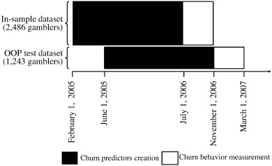

Fig. 1. Graphical display of the time window.

The time period in which the input variables or churn predictors are created is given in black, while the time span in which one observes whether a gambler does (not) come back to the website to gamble is represented in white. The in-sample dataset contains 2486 players, while an out-of-period (OOP) test dataset is considered containing 1243 players. The in-sample dataset is used for the 5 × 2-fold cv. In detail, ten prediction models are built during the training phase of the 5 × 2-fold cv, which are then validated on the in-sample test data of the 5 × 2-fold cv and the OOP test dataset. The OOP test dataset is added to the experiment, because a validation on unseen test data from another time frame is a more difficult exercise. A time window of 17 months is used to collect and construct the churn predictors for both the in-sample dataset and the OOP test dataset.

Furthermore, a four month period is considered to measure the churn behavior for each and every gambler in the datasets. In other words, a gambler is considered a churner when not having played during this four month period and vice versa. The churn incidence or the number of gamblers that stopped betting in the four month period equals to 30.64% for the in-sample dataset and 23.74% for the OOP test set. 60 churn predictors or gamblers' characteristics of the dataset are constructed and they are divided into two broad categories: behavioral information and demographic information. Appendix 1 gives an overview of all gamblers' information available to predict customers' churn.

## 6. Results

### 6.1. Classification performance

The results in Table 1, Table 2 follow from using the following experimental parameters. Per fold in the 5 × 2-fold cv, the RF and GAMens ensemble algorithms aggregate predictions from 1000 ensemble members. In other words, 1000 single prediction models are built whereby each is trained on a bootstrap sample from the original training dataset (Bagging), while Breiman's (2001) suggestion is followed to randomly select the square root of the total number of variables for each ensemble member model (RSM). More specifically, a random selection of the square root of 60 or eight variables for each ensemble member is considered.

Table 1. Performance overview of the churn prediction algorithms for the 5 × 2-fold CV.

| Evaluation metric | Set | Algorithm | Run 1 | Run 2 | Run 3 | Run 4 | 5 × 2-fold CV Runs Run 5 | 5 × 2-fold CV Runs Run 6 | Run 7 | Run 8 | Run 9 | Run 10 | Average | Standard Error |
| --- | --- | --- | --- | --- | --- | --- | --- | --- | --- | --- | --- | --- | --- | --- |
| TLD | Test | CART | 2.1333 | 2.2101 | 2.2123 | 2.3679 | 2.0279 | 2.3679 | 2.6864 | 2.1837 | 2.1860 | 2.0785 | 2.2454 | 0.1794 |
|  |  | RF | 2.8181 | 2.7363 | 2.8444 | 2.8152 | 2.7390 | 2.7100 | 2.7917 | 2.7926 | 2.8971 | 2.8678 | 2.8245 | 0.0581 |
|  |  | GAM | 2.3440 | 2.4732 | 2.4757 | 2.5784 | 2.4493 | 2.5784 | 2.5547 | 1.8943 | 2.6600 | 2.5784 | 2.4586 | 0.2062 |
|  |  | GAMens | 2.8707 | 2.7363 | 2.7363 | 2.7390 | 2.9204 | 2.7390 | 2.7917 | 2.7626 | 2.7917 | 2.7626 | 2.7824 | 0.0624 |
|  | OOP | CART | 2.7184 | 3.0922 | 2.9903 | 3.1941 | 2.4126 | 2.9563 | 3.3980 | 2.9563 | 3.0582 | 2.8543 | 2.9631 | 0.2537 |
|  |  | RF | 3.3641 | 3.5000 | 3.6359 | 3.3641 | 3.3980 | 3.5679 | 3.4660 | 3.3641 | 3.5340 | 3.5000 | 3.4694 | 0.0905 |
|  |  | GAM | 2.7184 | 2.8543 | 3.0242 | 2.8543 | 2.8543 | 2.9563 | 2.9223 | 1.8349 | 2.7864 | 2.7184 | 2.7524 | 0.3195 |
|  |  | GAMens | 3.3641 | 3.3301 | 3.4660 | 3.3301 | 3.4660 | 3.3980 | 3.2961 | 3.5000 | 3.4660 | 3.3980 | 3.4014 | 0.0670 |
| LI | TEST | CART | 0.7024 | 0.7213 | 0.6938 | 0.7179 | 0.7132 | 0.7159 | 0.7233 | 0.7171 | 0.6894 | 0.7089 | 0.7103 | 0.0110 |
|  |  | RF | 0.7593 | 0.7533 | 0.7558 | 0.7504 | 0.7577 | 0.7629 | 0.7585 | 0.7614 | 0.7613 | 0.7538 | 0.7574 | 0.0039 |
|  |  | GAM | 0.7071 | 0.7131 | 0.7376 | 0.7268 | 0.7053 | 0.7394 | 0.7303 | 0.6701 | 0.7200 | 0.7289 | 0.7178 | 0.0195 |
|  |  | GAMens | 0.7526 | 0.7549 | 0.7597 | 0.7470 | 0.7500 | 0.7530 | 0.7524 | 0.7512 | 0.7603 | 0.7488 | 0.7530 | 0.0041 |
|  | OOP | CART | 0.7486 | 0.7227 | 0.7101 | 0.7247 | 0.7554 | 0.6973 | 0.7453 | 0.7057 | 0.7215 | 0.7292 | 0.7260 | 0.0181 |
|  |  | RF | 0.7787 | 0.7747 | 0.7799 | 0.7739 | 0.7847 | 0.7746 | 0.7750 | 0.7768 | 0.7824 | 0.7746 | 0.7775 | 0.0036 |
|  |  | GAM | 0.7132 | 0.6881 | 0.7614 | 0.7136 | 0.7403 | 0.7315 | 0.7214 | 0.5823 | 0.7281 | 0.6908 | 0.7071 | 0.0464 |
|  |  | GAMens | 0.7797 | 0.7739 | 0.7814 | 0.7698 | 0.7844 | 0.7719 | 0.7742 | 0.7810 | 0.7803 | 0.7749 | 0.7772 | 0.0046 |

Table 2. Summary table of the average performance measures over the 5x2-fold cv.

[output not shown]

Note: in any row, performance measures that do share a common subscript are not significantly different at p < 0.05/6.

Table 1 provides a performance overview of the churn prediction algorithms for the 5 × 2-fold cv. The results on the in-sample test set (TEST) and the OOP test set are reported. In detail, the performances of the individual cross-validation runs are given, i.e. Run 1 till Run 10, the averaged performance over the ten runs (Average) and the standard error of the performance measure over the ten runs (Standard Error) are considered for TDL and LI.

A cell in Table 2 gives the average performance of an algorithm over the 5 × 2-fold cv. The significance between two algorithms is obtained by applying the nonparametric Wilcoxon-signed rank test which ranks the differences in performance over the ten cross-validation runs, ignoring the signs, and comparing the ranks for the positive and the negative differences (Demšar, 2006, Wilcoxon, 1945). The Bonferroni correction is applied to address the problem of multiple comparisons, six in this setting, and to take into account the family-wise error rate (Abdi, 2007). In any row, performance measures that do share a common subscript are not significantly different at the Bonferroni-corrected p value of 0.05/6.

Table 1 provides insight into the stability of the algorithms over the cross-validation runs by means of the standard error. In particular, Table 1 shows that the single algorithms, CART and GAM, are more sensitive to small changes in the training set than their ensemble counterparts, RF and GAMens. The standard errors for TDL and LI are systematically higher for CART and GAM than for RF and GAMens in both test cases, i.e. TEST and OOP.

Table 2 reveals the beneficial effect of ensemble algorithms over the corresponding single models. It is clear from Table 2 that GAMens has a significantly better performance than GAM, while RF performs substantially better than a single CART for TDL and LI in both test situations. The added value of CART over GAM or vice versa is not confirmed, while Table 2 confirms that the ensemble models, RF and GAMens, are very competitive, and thus their performances are not statistically different in this gambling setting.

In general, one can conclude that churn prediction is a very valuable tool to the traditional CRM palette in the gambling industry. The following section explores the churn predictors' importance of the strongest algorithms, i.e. random forests and GAMens.

### 6.2. Churn indicators importance

Next to the ability to generate accurate predictions, churn prediction should deliver insight into the drivers of customer churn. Hence, comprehensibility is an important characteristic of customer churn prediction models (Masand et al., 1999, Verbeke et al., 2011). However, while generally recognized for their strong classification performance, ensemble methods are sometimes reproached their black box nature, i.e., their reduced ability to deliver insights due to an increased model complexity. This study shows that this need not be the case by reporting variable importance scores, a by-product of the random forest algorithm that allows the analyst to measure the relative importance of each variable in the data set (Breiman, 2001).

This study concentrates on permutation-based variable importance scores, generally accepted as the most sophisticated and desirable variation (Strobl, Boulesteix, Zeileis, & Hothorn, 2007). The variable importance score of a particular variable is obtained by, for every member in the ensemble, calculating the difference in predictive accuracy on the out-of-bag data, and the predictive accuracy after randomly permuting the variable's values within the same data set. The out-of-bag data is simply the set of customers that were not selected in the bootstrap sample used as training data for that respective ensemble member. The global importance score is then the average difference in prediction performance, calculated over all the members in the ensemble (Breiman, 2001).

In Table 3, both for random forest and GAMens models, the 20 most important customer churn drivers are identified based on permutation-based variable importance scores. To offer additional insight into how churners and non-churners differ in terms of these characteristics, average values are provided for both the churners and non-churners, and these are compared using significance tests.

Table 3. 20 most important variables for random forests and GAMens based on variable importance scores and average variable value comparison between churners and non-churners.

[output not shown]

Note 1: Statiscally significant differences between churnes and non-churnes are indicated (p < 0.1(*) & p < 0.05(**)) based on paired T-tests for the comparison of means.

Note 2: Variables in bold appear uniquely for the respective technique.

## 7. Managerial implications

The results prove that employing a churn prediction model to identify those customers at risk of stopping gambling is more beneficial than randomly selecting customers out of the database for targeting purposes. The search towards more advanced algorithms by means of ensemble algorithms to optimize the churn prediction performance is a very meticulous task that could have a huge impact on the bottom-line profit of the company (Van den Poel & Larivière, 2004). Based on the formula of Neslin et al. (2006), the gain in profitability between two classification techniques for a change in TDL is defined as follows(3)$GAIN=Nα[γCLV+δ(1-γ)]β0ΔTDL$with N the total number of customers, α the percentage of the customer base contacted, β<sub>0</sub> the base-line churn rate, δ the cost of the customer incentive to the firm, γ the fraction of targeted would-be churners who decide to remain because of the incentive (i.e., the success rate of the incentive), CLV the customer lifetime value (i.e., the value to the firm if the customer is retained) and ∆<sub>TDL</sub> the difference in top decile lift between two classifiers. Based on the real-life bwin Interactive Entertainment dataset, and taking into account the different between CART versus RF and GAM versus GAMens in terms of TDL on the OOP, Table 4 summarizes the results with different γ and CLV, a cost of 50 Euros (δ), β<sub>0</sub> equal to 23.74% the base-line churn rate in the OOP and by setting Nα = 1 to put the gain on the customer level.

Table 4. Comparison of profitability gains per customer (in Euro) by using ensembles over single algorithms.

[output not shown]

Based on the results of Table 4 and knowing that gambling databases contain a large number of customers; this study encourages marketing analysts to focus on ensemble algorithms for customer churn prediction in order to optimize the identification of those customers at risk, and accordingly the bottom-line contribution per customer.

## 8. Conclusions

Nowadays gambling companies are searching for new alternative ways of building and retaining customer relationships. Churn prediction modeling is one of these alternatives and it ranks customers from most to least likely to churn based on the allocation of a churn probability to each customer in the customer database. Based on a real-life online gambling dataset obtained from bwin Interactive Entertainment, this study confirms that customer churn prediction is a valuable approach in the CRM portfolio of a gambling company.

The study shows the beneficial impact of ensemble algorithms over single prediction models in this customer churn prediction setting. This study highlights the advantages of the ensembles RF and GAMens, that is, robust and better prediction performance, than the single algorithms, CART and GAM. Although the performance of a prediction algorithm is the most important criterion to decide which algorithm to apply in a real-life setting, it is seldom considered as the only decision criterion. Three other criteria are placed in the balance when putting prediction algorithms into practice: the required expertise of the analyst, the running time of the algorithm and the availability in standard software packages. Firstly, running the ensemble learners RF and GAMens requires additional and specialized knowledge from the analyst in order to fully understand the functioning of the ensemble algorithms.

Additional training is necessary and costly. Secondly, the ensemble learners have, on average, a larger running time than the single models which is an additional element to consider when employing ensemble learners. Finally, ensemble learners are freely available in open source software environments like R or WEKA. However, an additional effort is required to use the ensemble toolbox and to integrate it with the existing predictive modeling software package used by the company.

Several avenues for further research are given. First, the results of this research should be extended to other types of gambling environments offering virtual poker tables. Our results are obtained by using data from bwin, in nature a sports betting operator. The dataset most probably contains players whose primary interest is sports gambling, while they probably choose poker as an additional game. Building a churn prediction model on data that includes customers who first shifted towards online gambling/sports betting in general would be interesting. Finally, churn prediction is only one side of the coin. Additional efforts could be spent to combine the event of churning with the profitability of the customers in order to truly identify high value churners.

## Acknowledgments

The authors thank “bwin” and the Cambridge Health Alliance for freely distributing the data, the editors for handling this paper through the reviewing process, and the reviewers for their insightful comments.

## Appendix 1. Overview of gamblers' characteristics

[output not shown]

Note: a session is defined as a day on which one or more bets are made.

## References

**Abdi, 2007**

H. Abdi**Bonferroni and Šidák corrections for multiple comparisons**

N.J. Salkind (Ed.), Encyclopedia of measurement and statistics, Sage, Thousand Oaks, CA (2007)

[Google Scholar](https://scholar.google.com/scholar_lookup?title=Bonferroni%20and%20%C5%A0id%C3%A1k%20corrections%20for%20multiple%20comparisons&publication_year=2007&author=H.%20Abdi)

**Andrade and Iyer, 2009**

E.B. Andrade, G. Iyer**Planned versus actual betting in sequential gambles**

Journal of Marketing Research, 46 (3) (2009), pp. 372-383

[CrossRef](https://doi.org/10.1509/jmkr.46.3.372)[View Record in Scopus](https://www.scopus.com/inward/record.url?eid=2-s2.0-68649101190&partnerID=10&rel=R3.0.0)[Google Scholar](https://scholar.google.com/scholar_lookup?title=Planned%20versus%20actual%20betting%20in%20sequential%20gambles&publication_year=2009&author=E.B.%20Andrade&author=G.%20Iyer)

**Athanassopoulos, 2000**

A.D. Athanassopoulos**Customer satisfaction cues to support market segmentation and explain switching behavior**

Journal of Business Research, 47 (3) (2000), pp. 191-207

[Article](https://www.sciencedirect.com/science/article/pii/S0148296398000605)[Download PDF](https://www.sciencedirect.com/science/article/pii/S0148296398000605/pdfft?md5=0083cb3f2bc81f3ba2d956f8394aeae4&pid=1-s2.0-S0148296398000605-main.pdf)[View Record in Scopus](https://www.scopus.com/inward/record.url?eid=2-s2.0-0034148454&partnerID=10&rel=R3.0.0)[Google Scholar](https://scholar.google.com/scholar_lookup?title=Customer%20satisfaction%20cues%20to%20support%20market%20segmentation%20and%20explain%20switching%20behavior&publication_year=2000&author=A.D.%20Athanassopoulos)

**Bauer and Kohavi, 1999**

E. Bauer, R. Kohavi**An empirical comparison of voting classification algorithms: Bagging, boosting, and variants**

Machine Learning, 36 (1–2) (1999), pp. 105-139

[View Record in Scopus](https://www.scopus.com/inward/record.url?eid=2-s2.0-0032645080&partnerID=10&rel=R3.0.0)Google Scholar

**Blattberg et al., 2008**

R.C. Blattberg, B.-D. Kim, S.A. Neslin**Database marketing: Analyzing and managing customers**

Springer, New York (NY) (2008)

[Google Scholar](https://scholar.google.com/scholar_lookup?title=Database%20marketing%3A%20Analyzing%20and%20managing%20customers&publication_year=2008&author=R.C.%20Blattberg&author=B.-D.%20Kim&author=S.A.%20Neslin)

**Bleichrodt and Schmidt, 2002**

H. Bleichrodt, U. Schmidt**A context-dependent model of the gambling effect**

Management Science, 48 (6) (2002), pp. 802-812

[View Record in Scopus](https://www.scopus.com/inward/record.url?eid=2-s2.0-0036602039&partnerID=10&rel=R3.0.0)[Google Scholar](https://scholar.google.com/scholar_lookup?title=A%20context-dependent%20model%20of%20the%20gambling%20effect&publication_year=2002&author=H.%20Bleichrodt&author=U.%20Schmidt)

**Bose and Chen, 2009**

I. Bose, X. Chen**Quantitative models for direct marketing: A review from systems perspective**

European Journal of Operational Research, 195 (1) (2009), pp. 1-16

[Article](https://www.sciencedirect.com/science/article/pii/S0377221708003512)[Download PDF](https://www.sciencedirect.com/science/article/pii/S0377221708003512/pdfft?md5=28fec2c4c49a0f7c6efda57e041a3d9f&pid=1-s2.0-S0377221708003512-main.pdf)[View Record in Scopus](https://www.scopus.com/inward/record.url?eid=2-s2.0-55949137626&partnerID=10&rel=R3.0.0)[Google Scholar](https://scholar.google.com/scholar_lookup?title=Quantitative%20models%20for%20direct%20marketing%3A%20A%20review%20from%20systems%20perspective&publication_year=2009&author=I.%20Bose&author=X.%20Chen)

**Braverman and Shaffer, 2010**

J. Braverman, H.J. Shaffer**How do gamblers start gambling: Identifying behavioral markers for high-risk Internet gambling**

European Journal of Public Health, 22 (2) (2010), pp. 273-278

Google Scholar

**Breiman, 1996**

L. Breiman**Bagging predictors**

Machine Learning, 24 (2) (1996), pp. 123-140

[CrossRef](https://doi.org/10.1007/BF00058655)[View Record in Scopus](https://www.scopus.com/inward/record.url?eid=2-s2.0-0001119012&partnerID=10&rel=R3.0.0)[Google Scholar](https://scholar.google.com/scholar_lookup?title=Bagging%20predictors&publication_year=1996&author=L.%20Breiman)

**Breiman, 2001**

L. Breiman**Random forests**

Machine Learning, 45 (1) (2001), pp. 5-32

[CrossRef](https://doi.org/10.1023/A:1010933404324)[View Record in Scopus](https://www.scopus.com/inward/record.url?eid=2-s2.0-0035478854&partnerID=10&rel=R3.0.0)[Google Scholar](https://scholar.google.com/scholar_lookup?title=Random%20forests&publication_year=2001&author=L.%20Breiman)

**Breiman et al., 1984**

L. Breiman, J.H. Friedman, R.A. Olsen, C.J. Stone**Classification and regression trees**

Chapman & Hall/CRC (1984)

[Google Scholar](https://scholar.google.com/scholar_lookup?title=Classification%20and%20regression%20trees&publication_year=1984&author=L.%20Breiman&author=J.H.%20Friedman&author=R.A.%20Olsen&author=C.J.%20Stone)

**Buckinx and Van den Poel, 2005**

W. Buckinx, D. Van den Poel**Customer base analysis: Partial defection of behaviorally loyal clients in a non-contractual FMCG retail setting**

European Journal of Operational Research, 164 (1) (2005), pp. 252-268

[Article](https://www.sciencedirect.com/science/article/pii/S0377221703009184)[Download PDF](https://www.sciencedirect.com/science/article/pii/S0377221703009184/pdfft?md5=e65d95412e53129834dfe66962db1e1b&pid=1-s2.0-S0377221703009184-main.pdf)[View Record in Scopus](https://www.scopus.com/inward/record.url?eid=2-s2.0-10444274107&partnerID=10&rel=R3.0.0)Google Scholar

**Cooper et al., 2008**

M.J. Cooper, C.F. Gwin, K.L. Wakefield**Cross-functional interface and disruption in CRM projects: Is marketing from Venus and information systems from Mars?**

Journal of Business Research, 61 (4) (2008), pp. 292-299

[Article](https://www.sciencedirect.com/science/article/pii/S0148296307002287)[Download PDF](https://www.sciencedirect.com/science/article/pii/S0148296307002287/pdfft?md5=455ab969d2a66e832797a4aa9bfc0d83&pid=1-s2.0-S0148296307002287-main.pdf)[View Record in Scopus](https://www.scopus.com/inward/record.url?eid=2-s2.0-39649098445&partnerID=10&rel=R3.0.0)[Google Scholar](https://scholar.google.com/scholar?q=Cross-functional%20interface%20and%20disruption%20in%20CRM%20projects:%20Is%20marketing%20from%20Venus%20and%20information%20systems%20from%20Mars)

**Coussement et al., 2010**

K. Coussement, D.F. Benoit, D. Van den Poel**Improved marketing decision making in a customer churn prediction context using generalized additive models**

Expert Systems with Applications, 37 (3) (2010), pp. 2132-2143

[Article](https://www.sciencedirect.com/science/article/pii/S0957417409007325)[Download PDF](https://www.sciencedirect.com/science/article/pii/S0957417409007325/pdfft?md5=d02376cf7cc8933a89472318c832c1a3&pid=1-s2.0-S0957417409007325-main.pdf)[View Record in Scopus](https://www.scopus.com/inward/record.url?eid=2-s2.0-70449526531&partnerID=10&rel=R3.0.0)Google Scholar

**Coussement and Van den Poel, 2008**

K. Coussement, D. Van den Poel**Churn prediction in subscription services: An application of support vector machines while comparing two parameter-selection techniques**

Expert Systems with Applications, 34 (1) (2008), pp. 313-327

[Article](https://www.sciencedirect.com/science/article/pii/S0957417406002806)[Download PDF](https://www.sciencedirect.com/science/article/pii/S0957417406002806/pdfft?md5=942186048f1b9a6aa536115088302e29&pid=1-s2.0-S0957417406002806-main.pdf)[View Record in Scopus](https://www.scopus.com/inward/record.url?eid=2-s2.0-34248524002&partnerID=10&rel=R3.0.0)Google Scholar

**Coussement and Van den Poel, 2009**

K. Coussement, D. Van den Poel**Improving customer attrition prediction by integrating emotions from client/company interaction emails and evaluating multiple classifiers**

Expert Systems with Applications, 36 (3) (2009), pp. 6127-6134

[Article](https://www.sciencedirect.com/science/article/pii/S095741740800479X)[Download PDF](https://www.sciencedirect.com/science/article/pii/S095741740800479X/pdfft?md5=41717f121517c2bb9a944e151634bc76&pid=1-s2.0-S095741740800479X-main.pdf)[View Record in Scopus](https://www.scopus.com/inward/record.url?eid=2-s2.0-58349110712&partnerID=10&rel=R3.0.0)[Google Scholar](https://scholar.google.com/scholar?q=Improving%20customer%20attrition%20prediction%20by%20integrating%20emotions%20from%20clientcompany%20interaction%20emails%20and%20evaluating%20multiple%20classifiers)

**Cronce and Corbin, 2010**

J.M. Cronce, W.R. Corbin**Effects of alcohol and initial gambling outcomes on within-session gambling behavior**

Experimental and Clinical Psychopharmacology, 18 (2) (2010), pp. 145-157

[CrossRef](https://doi.org/10.1037/a0019114)[View Record in Scopus](https://www.scopus.com/inward/record.url?eid=2-s2.0-77952804736&partnerID=10&rel=R3.0.0)Google Scholar

**Crone et al., 2006**

S.F. Crone, S. Lessmann, R. Stahlbock**The impact of preprocessing on data mining: An evaluation of classifier sensitivity in direct marketing**

European Journal of Operational Research, 173 (3) (2006), pp. 781-800

[Article](https://www.sciencedirect.com/science/article/pii/S0377221705006739)[Download PDF](https://www.sciencedirect.com/science/article/pii/S0377221705006739/pdfft?md5=a2335b5f7ecf3b7d487742373d9dfd42&pid=1-s2.0-S0377221705006739-main.pdf)[View Record in Scopus](https://www.scopus.com/inward/record.url?eid=2-s2.0-33744976067&partnerID=10&rel=R3.0.0)Google Scholar

**Cui et al., 2006**

G. Cui, M.L. Wong, H.-K. Lui**Machine learning for direct marketing response models: Bayesian networks with evolutionary programming**

Management Science, 52 (4) (2006), pp. 597-612

[CrossRef](https://doi.org/10.1287/mnsc.1060.0514)[View Record in Scopus](https://www.scopus.com/inward/record.url?eid=2-s2.0-33645817013&partnerID=10&rel=R3.0.0)Google Scholar

**Dana and Knetter, 1994**

J.D. Dana, M.M. Knetter**Learning and efficiency in a gambling market**

Management Science, 40 (10) (1994), pp. 1317-1328

[CrossRef](https://doi.org/10.1287/mnsc.40.10.1317)[View Record in Scopus](https://www.scopus.com/inward/record.url?eid=2-s2.0-0028531782&partnerID=10&rel=R3.0.0)[Google Scholar](https://scholar.google.com/scholar_lookup?title=Learning%20and%20efficiency%20in%20a%20gambling%20market&publication_year=1994&author=J.D.%20Dana&author=M.M.%20Knetter)

**De Bock et al., 2010**

K.W. De Bock, K. Coussement, D. Van den Poel**Ensemble classification based on generalized additive models**

Computational Statistics & Data Analysis, 54 (6) (2010), pp. 1535-1546

[Article](https://www.sciencedirect.com/science/article/pii/S0167947309004654)[Download PDF](https://www.sciencedirect.com/science/article/pii/S0167947309004654/pdfft?md5=8d01350136ffd636bfa3e3bc28e88c1e&pid=1-s2.0-S0167947309004654-main.pdf)[View Record in Scopus](https://www.scopus.com/inward/record.url?eid=2-s2.0-77249118137&partnerID=10&rel=R3.0.0)Google Scholar

**Demšar, 2006**

J. Demšar**Statistical comparisons of classifiers over multiple data sets**

Journal of Machine Learning Research, 7 (2006), pp. 1-30

[View Record in Scopus](https://www.scopus.com/inward/record.url?eid=2-s2.0-29644438050&partnerID=10&rel=R3.0.0)[Google Scholar](https://scholar.google.com/scholar_lookup?title=Statistical%20comparisons%20of%20classifiers%20over%20multiple%20data%20sets&publication_year=2006&author=J.%20Dem%C5%A1ar)

**Dietterich, 2000**

T.G. Dietterich**An experimental comparison of three methods for constructing ensembles of decision trees: Bagging, boosting, and randomization**

Machine Learning, 40 (2) (2000), pp. 139-157

[View Record in Scopus](https://www.scopus.com/inward/record.url?eid=2-s2.0-0034250160&partnerID=10&rel=R3.0.0)Google Scholar

**Duda et al., 2001**

R.O. Duda, E. Hart, D.G. Stork**Pattern classificaiton**

John Wiley & Sons, New York, NY (2001)

[Google Scholar](https://scholar.google.com/scholar_lookup?title=Pattern%20classificaiton&publication_year=2001&author=R.O.%20Duda&author=E.%20Hart&author=D.G.%20Stork)

**Fiedler and Wilcke, 2011**

I. Fiedler, A.-C. Wilcke**Der Markt für Onlinepoker: Spielerherkunft und Spielerverhalten**

BoD, Norderstedt (2011)

[Google Scholar](https://scholar.google.com/scholar_lookup?title=Der%20Markt%20f%C3%BCr%20Onlinepoker%3A%20Spielerherkunft%20und%20Spielerverhalten&publication_year=2011&author=I.%20Fiedler&author=A.-C.%20Wilcke)

**Grant and Xie, 2007**

S.J. Grant, Y. Xie**Hedging your bets and assessing the outcome**

Journal of Marketing Research, 44 (3) (2007), pp. 516-524

[CrossRef](https://doi.org/10.1509/jmkr.44.3.516)[View Record in Scopus](https://www.scopus.com/inward/record.url?eid=2-s2.0-34548782635&partnerID=10&rel=R3.0.0)[Google Scholar](https://scholar.google.com/scholar_lookup?title=Hedging%20your%20bets%20and%20assessing%20the%20outcome&publication_year=2007&author=S.J.%20Grant&author=Y.%20Xie)

**Hastie and Tibshirani, 1986**

T. Hastie, R. Tibshirani**Generalized additive models**

Statistical Science, 1 (3) (1986), pp. 297-318

[View Record in Scopus](https://www.scopus.com/inward/record.url?eid=2-s2.0-85093403289&partnerID=10&rel=R3.0.0)[Google Scholar](https://scholar.google.com/scholar_lookup?title=Generalized%20additive%20models&publication_year=1986&author=T.%20Hastie&author=R.%20Tibshirani)

**Hastie and Tibshirani, 1990**

T. Hastie, R. Tibshirani**Generalized additive models**

Chapman and Hall, London (1990)

[Google Scholar](https://scholar.google.com/scholar_lookup?title=Generalized%20additive%20models&publication_year=1990&author=T.%20Hastie&author=R.%20Tibshirani)

**Ho, 1998**

T.K. Ho**The random subspace method for constructing decision forests**

IEEE Transactions on Pattern Analysis and Machine Intelligence, 20 (8) (1998), pp. 832-844

[View Record in Scopus](https://www.scopus.com/inward/record.url?eid=2-s2.0-0032139235&partnerID=10&rel=R3.0.0)[Google Scholar](https://scholar.google.com/scholar_lookup?title=The%20random%20subspace%20method%20for%20constructing%20decision%20forests&publication_year=1998&author=T.K.%20Ho)

**Humphreys, 2010**

A. Humphreys**Megamarketing: The creation of markets as a social process**

Journal of Marketing, 74 (2) (2010), pp. 1-19

[View Record in Scopus](https://www.scopus.com/inward/record.url?eid=2-s2.0-77949515917&partnerID=10&rel=R3.0.0)[Google Scholar](https://scholar.google.com/scholar_lookup?title=Megamarketing%3A%20The%20creation%20of%20markets%20as%20a%20social%20process&publication_year=2010&author=A.%20Humphreys)

**Jolley et al., 2006**

B. Jolley, R. Mizerski, D. Olaru**How habit and satisfaction affects player retention for online gambling**

Journal of Business Research, 59 (6) (2006), pp. 770-777

[Article](https://www.sciencedirect.com/science/article/pii/S0148296306000300)[Download PDF](https://www.sciencedirect.com/science/article/pii/S0148296306000300/pdfft?md5=8cf7afaee9213f930c6b6fcf2b5ff1df&pid=1-s2.0-S0148296306000300-main.pdf)[View Record in Scopus](https://www.scopus.com/inward/record.url?eid=2-s2.0-33747353091&partnerID=10&rel=R3.0.0)Google Scholar

**Keaveney and Parthasarathy, 2001**

S.M. Keaveney, M. Parthasarathy**Customer switching behavior in online services: An exploratory study of the role of selected attitudinal, behavioral, and demographic factors**

Journal of the Academy of Marketing Science, 29 (4) (2001), pp. 374-390

[View Record in Scopus](https://www.scopus.com/inward/record.url?eid=2-s2.0-23044530150&partnerID=10&rel=R3.0.0)Google Scholar

**Ko et al., 2008**

E. Ko, S.H. Kim, M. Kim, J.Y. Woo**Organizational characteristics and the CRM adoption process**

Journal of Business Research, 61 (1) (2008), pp. 65-74

[Article](https://www.sciencedirect.com/science/article/pii/S014829630700135X)[Download PDF](https://www.sciencedirect.com/science/article/pii/S014829630700135X/pdfft?md5=8899bb733475f78c40ec60c33a39374e&pid=1-s2.0-S014829630700135X-main.pdf)[View Record in Scopus](https://www.scopus.com/inward/record.url?eid=2-s2.0-35948951508&partnerID=10&rel=R3.0.0)[Google Scholar](https://scholar.google.com/scholar_lookup?title=Organizational%20characteristics%20and%20the%20CRM%20adoption%20process&publication_year=2008&author=E.%20Ko&author=S.H.%20Kim&author=M.%20Kim&author=J.Y.%20Woo)

**Kuncheva, 2004**

L.I. Kuncheva**Combining pattern classifiers: Methods and algorithms**

John Wiley & Sons, Hoboken, New Jersey (2004)

[Google Scholar](https://scholar.google.com/scholar_lookup?title=Combining%20pattern%20classifiers%3A%20Methods%20and%20algorithms&publication_year=2004&author=L.I.%20Kuncheva)

**Kuncheva and Rodríguez, 2007**

L.I. Kuncheva, J.J. Rodríguez**Classifier ensembles with a random linear oracle**

IEEE Transactions on Knowledge and Data Engineering, 19 (4) (2007), pp. 500-508

[View Record in Scopus](https://www.scopus.com/inward/record.url?eid=2-s2.0-37249077843&partnerID=10&rel=R3.0.0)[Google Scholar](https://scholar.google.com/scholar_lookup?title=Classifier%20ensembles%20with%20a%20random%20linear%20oracle&publication_year=2007&author=L.I.%20Kuncheva&author=J.J.%20Rodr%C3%ADguez)

**LaBrie and Shaffer, 2011**

R.A. LaBrie, H.J. Shaffer**Identifying behavioral markers of disordered Internet sports gambling**

Addiction Research & Theory, 19 (1) (2011), pp. 56-65

[CrossRef](https://doi.org/10.3109/16066359.2010.512106)[View Record in Scopus](https://www.scopus.com/inward/record.url?eid=2-s2.0-78651341079&partnerID=10&rel=R3.0.0)[Google Scholar](https://scholar.google.com/scholar_lookup?title=Identifying%20behavioral%20markers%20of%20disordered%20Internet%20sports%20gambling&publication_year=2011&author=R.A.%20LaBrie&author=H.J.%20Shaffer)

**Lal et al., 2001**

R. Lal, P. Martone Carrolo, Harrah's entertainment

Inc. Harvard Business School Publishing Case Series (2001), pp. 1-16

[View Record in Scopus](https://www.scopus.com/inward/record.url?eid=2-s2.0-84885869579&partnerID=10&rel=R3.0.0)

**Lam, 2006**

D. Lam**The influence of religiosity on gambling participation**

Journal of Gambling Studies, 22 (3) (2006), pp. 305-320

[CrossRef](https://doi.org/10.1007/s10899-006-9018-4)[View Record in Scopus](https://www.scopus.com/inward/record.url?eid=2-s2.0-33749357075&partnerID=10&rel=R3.0.0)[Google Scholar](https://scholar.google.com/scholar_lookup?title=The%20influence%20of%20religiosity%20on%20gambling%20participation&publication_year=2006&author=D.%20Lam)

**Lam, 2007**

D. Lam**An exploratory study of gambling motivations and their impact on the purchase frequencies of various gambling products**

Psychology and Marketing, 24 (9) (2007), pp. 815-827

[CrossRef](https://doi.org/10.1002/mar.20185)[View Record in Scopus](https://www.scopus.com/inward/record.url?eid=2-s2.0-34548191222&partnerID=10&rel=R3.0.0)Google Scholar

**Lam and Mizerski, 2009**

D. Lam, R. Mizerski**An investigation into gambling purchases using the NBD and NBD-Dirichlet models**

Marketing Letters, 20 (3) (2009), pp. 263-276

[CrossRef](https://doi.org/10.1007/s11002-009-9073-6)[View Record in Scopus](https://www.scopus.com/inward/record.url?eid=2-s2.0-70349336349&partnerID=10&rel=R3.0.0)[Google Scholar](https://scholar.google.com/scholar_lookup?title=An%20investigation%20into%20gambling%20purchases%20using%20the%20NBD%20and%20NBD-Dirichlet%20models&publication_year=2009&author=D.%20Lam&author=R.%20Mizerski)

**Lemmens and Croux, 2006**

A. Lemmens, C. Croux**Bagging and boosting classification trees to predict churn**

Journal of Marketing Research, 43 (2) (2006), pp. 276-286

[CrossRef](https://doi.org/10.1509/jmkr.43.2.276)[View Record in Scopus](https://www.scopus.com/inward/record.url?eid=2-s2.0-33744526493&partnerID=10&rel=R3.0.0)[Google Scholar](https://scholar.google.com/scholar_lookup?title=Bagging%20and%20boosting%20classification%20trees%20to%20predict%20churn&publication_year=2006&author=A.%20Lemmens&author=C.%20Croux)

**Malthouse, 2001**

E.C. Malthouse**Assessing the performance of direct marketing scoring models**

Journal of Interactive Marketing, 15 (1) (2001), pp. 49-62

[Article](https://www.sciencedirect.com/science/article/pii/S1094996801701739)[Download PDF](https://www.sciencedirect.com/science/article/pii/S1094996801701739/pdf?md5=0e2d3f9e9599ee9eaff9e9eea2d736c3&pid=1-s2.0-S1094996801701739-main.pdf)[View Record in Scopus](https://www.scopus.com/inward/record.url?eid=2-s2.0-0012904873&partnerID=10&rel=R3.0.0)[Google Scholar](https://scholar.google.com/scholar_lookup?title=Assessing%20the%20performance%20of%20direct%20marketing%20scoring%20models&publication_year=2001&author=E.C.%20Malthouse)

**Masand et al., 1999**

B. Masand, P. Datta, D. Mani, B. Li**CHAMP: A prototype for automated cellular churn prediction**

Data Mining and Knowledge Discovery, 3 (2) (1999), pp. 219-225

[View Record in Scopus](https://www.scopus.com/inward/record.url?eid=2-s2.0-27144521729&partnerID=10&rel=R3.0.0)Google Scholar

**McCarty and Hastak, 2007**

J.A. McCarty, M. Hastak**Segmentation approaches in data-mining: A comparison of RFM, CHAID, and logistic regression**

Journal of Business Research, 60 (6) (2007), pp. 656-662

[Article](https://www.sciencedirect.com/science/article/pii/S0148296306002323)[Download PDF](https://www.sciencedirect.com/science/article/pii/S0148296306002323/pdfft?md5=132e408ca3071038d9aa6e524e5c8b6f&pid=1-s2.0-S0148296306002323-main.pdf)[View Record in Scopus](https://www.scopus.com/inward/record.url?eid=2-s2.0-34247603517&partnerID=10&rel=R3.0.0)Google Scholar

**McDaniel and Zuckerman, 2003**

S.R. McDaniel, M. Zuckerman**The relationship of impulsive sensation seeking and gender to interest and participation in gambling activities**

Personality and Individual Differences, 35 (6) (2003), pp. 1385-1400

[Article](https://www.sciencedirect.com/science/article/pii/S0191886902003574)[Download PDF](https://www.sciencedirect.com/science/article/pii/S0191886902003574/pdfft?md5=bef91b43e6da97ab5a24e9f9f0559e43&pid=1-s2.0-S0191886902003574-main.pdf)[View Record in Scopus](https://www.scopus.com/inward/record.url?eid=2-s2.0-0041864113&partnerID=10&rel=R3.0.0)Google Scholar

**Mizerski et al., 2004**

R.W. Mizerski, R. Miller, K. Mizerski, D. Lam**The stochastic nature of purchasing a state's lottery products**

Australasian Marketing Journal, 12 (3) (2004), pp. 56-69

[View Record in Scopus](https://www.scopus.com/inward/record.url?eid=2-s2.0-70349318240&partnerID=10&rel=R3.0.0)[Google Scholar](https://scholar.google.com/scholar?q=The%20stochastic%20nature%20of%20purchasing%20a%20states%20lottery%20products)

**Mowen et al., 2009**

J.C. Mowen, X. Fang, K. Scott**A hierarchical model approach for identifying the trait antecedents of general gambling propensity and of four gambling-related genres**

Journal of Business Research, 62 (12) (2009), pp. 1262-1268

[Article](https://www.sciencedirect.com/science/article/pii/S0148296309000034)[Download PDF](https://www.sciencedirect.com/science/article/pii/S0148296309000034/pdfft?md5=2f490ccd0a72916ea3f948a62d06ee24&pid=1-s2.0-S0148296309000034-main.pdf)[View Record in Scopus](https://www.scopus.com/inward/record.url?eid=2-s2.0-70349986403&partnerID=10&rel=R3.0.0)Google Scholar

**Murthy, 1998**

S.K. Murthy**Automatic construction of decision trees from data: A multi-disciplinary survey**

Data Mining and Knowledge Discovery, 2 (1998), pp. 345-389

[View Record in Scopus](https://www.scopus.com/inward/record.url?eid=2-s2.0-0002431740&partnerID=10&rel=R3.0.0)[Google Scholar](https://scholar.google.com/scholar_lookup?title=Automatic%20construction%20of%20decision%20trees%20from%20data%3A%20A%20multi-disciplinary%20survey&publication_year=1998&author=S.K.%20Murthy)

**National Gambling Impact Study Commission, 1999**

National Gambling Impact Study Commission

Final report (1999)

(Washington, DC)http://govinfo.library.unt.edu/ngisc/index.html

[Google Scholar](https://scholar.google.com/scholar_lookup?title=Final%20report&publication_year=1999&author=National%20Gambling%20Impact%20Study%20Commission)

**Neslin et al., 2006**

S.A. Neslin, S. Gupta, W. Kamakura, J.X. Lu, C.H. Mason**Defection detection: Measuring and understanding the predictive accuracy of customer churn models**

Journal of Marketing Research, 43 (2) (2006), pp. 204-211

[CrossRef](https://doi.org/10.1509/jmkr.43.2.204)[View Record in Scopus](https://www.scopus.com/inward/record.url?eid=2-s2.0-33744509693&partnerID=10&rel=R3.0.0)Google Scholar

**Oh and Hsu, 2001**

H. Oh, C.H.C. Hsu**Volitional degrees of gambling behaviours**

Annals of Tourism Research, 28 (3) (2001), pp. 618-637

[Article](https://www.sciencedirect.com/science/article/pii/S0160738300000669)[Download PDF](https://www.sciencedirect.com/science/article/pii/S0160738300000669/pdfft?md5=eac1362e4ea475b6eef9d544b922a6e3&pid=1-s2.0-S0160738300000669-main.pdf)[View Record in Scopus](https://www.scopus.com/inward/record.url?eid=2-s2.0-0035018633&partnerID=10&rel=R3.0.0)[Google Scholar](https://scholar.google.com/scholar_lookup?title=Volitional%20degrees%20of%20gambling%20behaviours&publication_year=2001&author=H.%20Oh&author=C.H.C.%20Hsu)

**Productivity Commission, 1999**

Productivity Commission

Australia's gambling industries: Inquiry reports, vol. 1–3, Media and Publications, Melbourne, Australia (1999), p. 10

**Roehl, 1999**

W.S. Roehl**Quality of life issues in a casino destination**

Journal of Business Research, 44 (3) (1999), pp. 223-229

[Article](https://www.sciencedirect.com/science/article/pii/S0148296397002038)[Download PDF](https://www.sciencedirect.com/science/article/pii/S0148296397002038/pdfft?md5=724e1e9726a9fc160d4f2e621031aedb&pid=1-s2.0-S0148296397002038-main.pdf)[View Record in Scopus](https://www.scopus.com/inward/record.url?eid=2-s2.0-0033096007&partnerID=10&rel=R3.0.0)[Google Scholar](https://scholar.google.com/scholar_lookup?title=Quality%20of%20life%20issues%20in%20a%20casino%20destination&publication_year=1999&author=W.S.%20Roehl)

**Seybert and Bloomfield, 2009**

N. Seybert, R. Bloomfield**Contagion of wishful thinking in markets**

Management Science, 55 (5) (2009), pp. 738-751

[CrossRef](https://doi.org/10.1287/mnsc.1080.0973)[View Record in Scopus](https://www.scopus.com/inward/record.url?eid=2-s2.0-65249152474&partnerID=10&rel=R3.0.0)[Google Scholar](https://scholar.google.com/scholar_lookup?title=Contagion%20of%20wishful%20thinking%20in%20markets&publication_year=2009&author=N.%20Seybert&author=R.%20Bloomfield)

**Smith et al., 2009**

G. Smith, M. Levere, R. Kurtzman**Poker player behavior after big wins and big losses**

Management Science, 55 (9) (2009), pp. 1547-1555

[CrossRef](https://doi.org/10.1287/mnsc.1090.1044)[View Record in Scopus](https://www.scopus.com/inward/record.url?eid=2-s2.0-70349314631&partnerID=10&rel=R3.0.0)[Google Scholar](https://scholar.google.com/scholar_lookup?title=Poker%20player%20behavior%20after%20big%20wins%20and%20big%20losses&publication_year=2009&author=G.%20Smith&author=M.%20Levere&author=R.%20Kurtzman)

**Smith et al., 2000**

K.A. Smith, R.J. Willis, M. Brooks**An analysis of customer retention and insurance claim patterns using data mining: A case study**

Journal of the Operational Research Society, 51 (5) (2000), pp. 532-541

[View Record in Scopus](https://www.scopus.com/inward/record.url?eid=2-s2.0-0033748604&partnerID=10&rel=R3.0.0)Google Scholar

**Steinberg and Colla, 1998**

D. Steinberg, P. Colla**CART (Classification and Regression Trees)**

Salford Systems, San Diego, CA (1998)

[Google Scholar](https://scholar.google.com/scholar?q=CART)

**Stekler et al., 2010**

H.O. Stekler, D. Sendor, R. Verlander**Issues in sports forecasting**

International Journal of Forecasting, 26 (3) (2010), pp. 606-621

[Article](https://www.sciencedirect.com/science/article/pii/S0169207010000099)[Download PDF](https://www.sciencedirect.com/science/article/pii/S0169207010000099/pdfft?md5=0c0bb7128f6172d93d0a2b3899f9a495&pid=1-s2.0-S0169207010000099-main.pdf)[View Record in Scopus](https://www.scopus.com/inward/record.url?eid=2-s2.0-77952291402&partnerID=10&rel=R3.0.0)[Google Scholar](https://scholar.google.com/scholar_lookup?title=Issues%20in%20sports%20forecasting&publication_year=2010&author=H.O.%20Stekler&author=D.%20Sendor&author=R.%20Verlander)

**Strobl et al., 2007**

C. Strobl, A.-L. Boulesteix, A. Zeileis, T. Hothorn**Bias in random forest variable importance measures: Illustrations, sources and a solution**

BMC Bioinformatics, 8 (1) (2007), pp. 8-25

[View Record in Scopus](https://www.scopus.com/inward/record.url?eid=2-s2.0-85017481971&partnerID=10&rel=R3.0.0)Google Scholar

**Van den Poel and Larivière, 2004**

D. Van den Poel, B. Larivière**Customer attrition analysis for financial services using proportional hazard models**

European Journal of Operational Research, 157 (1) (2004), pp. 196-217

[Article](https://www.sciencedirect.com/science/article/pii/S0377221703000699)[Download PDF](https://www.sciencedirect.com/science/article/pii/S0377221703000699/pdfft?md5=5e69b309c63d6a81e82c930d84c6792e&pid=1-s2.0-S0377221703000699-main.pdf)[View Record in Scopus](https://www.scopus.com/inward/record.url?eid=2-s2.0-1842478892&partnerID=10&rel=R3.0.0)Google Scholar

**van Wezel and Potharst, 2007**

M. van Wezel, R. Potharst**Improved customer choice predictions using ensemble methods**

European Journal of Operational Research, 181 (1) (2007), pp. 436-452

[Article](https://www.sciencedirect.com/science/article/pii/S0377221706003900)[Download PDF](https://www.sciencedirect.com/science/article/pii/S0377221706003900/pdfft?md5=38bdc533a182cd181c1b673827269b4b&pid=1-s2.0-S0377221706003900-main.pdf)[View Record in Scopus](https://www.scopus.com/inward/record.url?eid=2-s2.0-33847289259&partnerID=10&rel=R3.0.0)[Google Scholar](https://scholar.google.com/scholar_lookup?title=Improved%20customer%20choice%20predictions%20using%20ensemble%20methods&publication_year=2007&author=M.%20van%20Wezel&author=R.%20Potharst)

**Verbeke et al., 2011**

W. Verbeke, D. Martens, C. Mues, B. Baesens**Building comprehensible customer churn prediction models with advanced rule induction techniques**

Expert Systems with Applications, 38 (3) (2011), pp. 2354-2364

[Article](https://www.sciencedirect.com/science/article/pii/S0957417410008067)[Download PDF](https://www.sciencedirect.com/science/article/pii/S0957417410008067/pdfft?md5=8f822ad3f57421357b364a44cd122b30&pid=1-s2.0-S0957417410008067-main.pdf)[View Record in Scopus](https://www.scopus.com/inward/record.url?eid=2-s2.0-78049530278&partnerID=10&rel=R3.0.0)Google Scholar

**Wilcoxon, 1945**

F. Wilcoxon**Individual comparisons by ranking methods**

Biometrics, 1 (1945), pp. 80-83

[CrossRef](https://doi.org/10.2307/3001968)[View Record in Scopus](https://www.scopus.com/inward/record.url?eid=2-s2.0-84980408619&partnerID=10&rel=R3.0.0)[Google Scholar](https://scholar.google.com/scholar_lookup?title=Individual%20comparisons%20by%20ranking%20methods&publication_year=1945&author=F.%20Wilcoxon)

**Witten and Frank, 2000**

I. Witten, E. Frank**Data mining: Practical machine learning tools and techniques with java implementations**

Morgan Kaufmann, San Francisco, CA (2000)

Google Scholar

Copyright © 2012 Elsevier Inc. All rights reserved.